# R Notebook

```r
library(tidyverse)
library(plotrix)
library(ggstatsplot)
library(ggridges)
```

**Principles of Data Visualization and Introduction to ggplot2**

And lets preview this data:

```r
# preview data
head(inc)
```

|  | Rank | Name | Growth_Rate | Revenue | Industry | Employees | City | State |
| --- | --- | --- | --- | --- | --- | --- | --- | --- |
| 1 | 1 | Fuhu | 421.48 | 1.179e+08 | Consumer Products & Services | 104 | El Segundo | CA |
| 2 | 2 | FederalConference.com | 248.31 | 4.960e+07 | Government Services | 51 | Dumfries | VA |
| 3 | 3 | The HCI Group | 245.45 | 2.550e+07 | Health | 132 | Jacksonville | FL |
| 4 | 4 | Bridger | 233.08 | 1.900e+09 | Energy | 50 | Addison | TX |
| 5 | 5 | DataXu | 213.37 | 8.700e+07 | Advertising & Marketing | 220 | Boston | MA |
| 6 | 6 | MileStone Community Builders | 179.38 | 4.570e+07 | Real Estate | 63 | Austin | TX |

```r
# view data summary
summary(inc)
```

```
      Rank          Name            Growth_Rate         Revenue
 Min.   :   1   Length:5001        Min.   :  0.340   Min.   :2.000e+06
 1st Qu.:1252   Class :character   1st Qu.:  0.770   1st Qu.:5.100e+06
 Median :2502   Mode  :character   Median :  1.420   Median :1.090e+07
 Mean   :2502                      Mean   :  4.612   Mean   :4.822e+07
 3rd Qu.:3751                      3rd Qu.:  3.290   3rd Qu.:2.860e+07
 Max.   :5000                      Max.   :421.480   Max.   :1.010e+10

   Industry           Employees           City
 Length:5001        Min.   :    1.0   Length:5001
 Class :character   1st Qu.:   25.0   Class :character
 Mode  :character   Median :   53.0   Mode  :character
                    Mean   :  232.7
                    3rd Qu.:  132.0
                    Max.   :66803.0
                    NA's   :12
    State
 Length:5001
 Class :character
 Mode  :character
```

Think a bit on what these summaries mean. Use the space below to add some more relevant non-visual exploratory information you think helps you understand this data:

Ok, for me its easier to write out and define what they mean:

- `Rank` is the rank of the company in regard to `Growth Rate` (ordinal)
- `Name` is the name of the company
- `Growth Rate` is the rate at which the company has grown over a period of time (continuous).
- `Revenue` is the amount of money each company has made (continuous)
- `Industry` is a categorical variable stating the industry type of the company
- `Employees` are the number of employees (continuous)
- `City` is the city where the company is located
- `State` is the state where the company is located

So for any object data types the `summary()` function is simply counting the records and defining the class type as `character`. For numeric data types we are getting some summary statistics including: - Min - 1st Quartile - Median - Mean - 3rd Quartile - Max - How many NA’s

Some grouping by categorical data would help me better understand where companies that have high `Growth Rate` tend to be located.

```r
# Insert your code here, create more chunks as necessary
(top_5_states <- inc %>%
  group_by(State) %>%
  tally(sort = T) %>%
  head())
```

| State | n |
| --- | --- |
| CA | 701 |
| TX | 387 |
| NY | 311 |
| VA | 283 |
| FL | 282 |
| IL | 273 |

```r
# top 5 states with most companies and average growth rate
inc %>%
  group_by(State) %>%
  summarise(n = n(), mean_growth_rate = round(mean(Growth_Rate),2)) %>%
  arrange(desc(n)) %>%
  head() %>%
  arrange(desc(mean_growth_rate))
```

| State | n | mean_growth_rate |
| --- | --- | --- |
| TX | 387 | 6.02 |
| CA | 701 | 5.90 |
| FL | 282 | 5.85 |
| VA | 283 | 4.88 |
| NY | 311 | 4.37 |
| IL | 273 | 3.74 |

## Question 1

Create a graph that shows the distribution of companies in the dataset by State (ie how many are in each state). There are a lot of States, so consider which axis you should use. This visualization is ultimately going to be consumed on a ‘portrait’ oriented screen (ie taller than wide), which should further guide your layout choices.

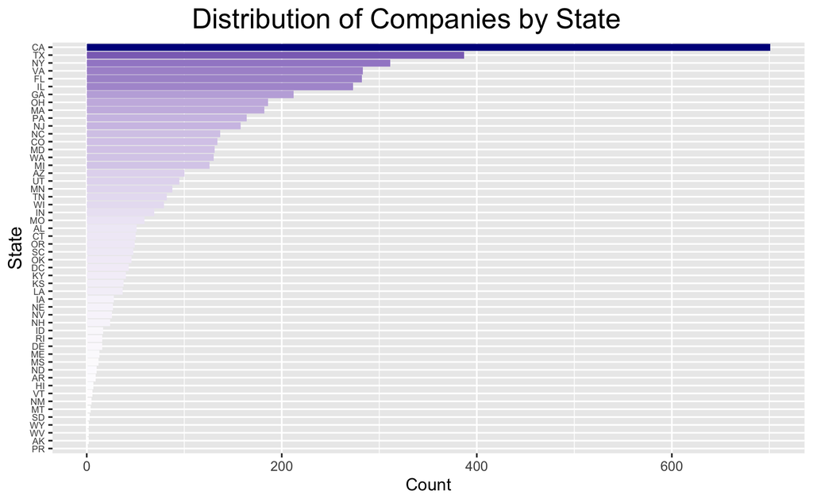

```r
# Answer Question 1 here
inc %>%
  group_by(State) %>%
  summarise(count = n()) %>%
  ggplot() +
    geom_bar(aes(count, reorder(State, count), fill = count),
             stat = "identity") +
    scale_fill_gradient(low = "white", high = "darkblue") +
    labs(x="Count", y="State",
         title = "Distribution of Companies by State") +
    theme(plot.title.position = "plot",
          plot.title = element_text(hjust = 0.5,
                                    size = 18),
          axis.text.y = element_text(size = 6),
          axis.title.y = element_text(size = 12),
          legend.position = "none")
```

## Question 2

Lets dig in on the state with the 3rd most companies in the data set. Imagine you work for the state and are interested in how many people are employed by companies in different industries. Create a plot that shows the average and/or median employment by industry for companies in this state (only use cases with full data, use R’s `complete.cases()` function.) In addition to this, your graph should show how variable the ranges are, and you should deal with outliers.

```r
# look at summary for NY
summary(inc_ny$Employees)
```

```
   Min. 1st Qu.  Median    Mean 3rd Qu.    Max.
    1.0    21.0    45.0   271.3   105.5 32000.0
```

Let’s visualize `Employees` in a boxplot

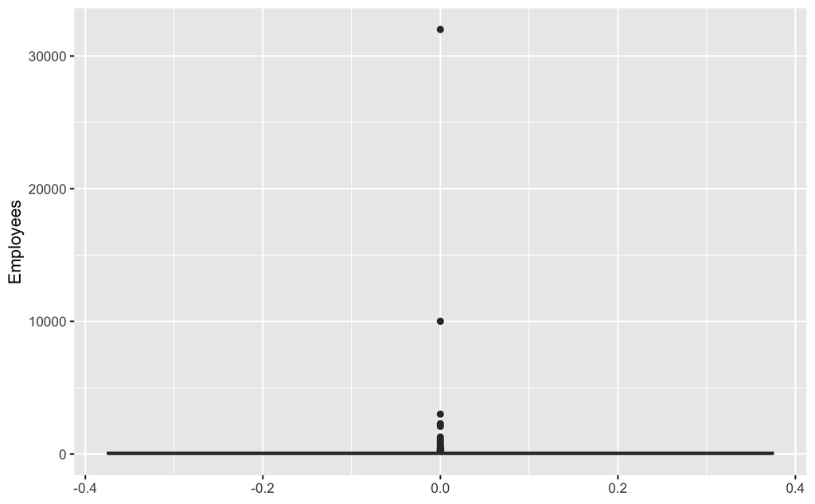

Looks like we have some extreme variation, wonder what industries this is in.

Let’s group by industry and create min, max, mean and median columns sorted decreasing by max.

First let’s create custom function.

```r
# create group by function for particular column
# aggregates by another and sorts descending by another (default max)
groupby_column <- function(df, col_grp, agg_col, sort_col=max_grp) {

  # quote columns
  col_grp <- dplyr::enquo(col_grp)
  agg_col <- dplyr::enquo(agg_col)
  sort_col <- dplyr::enquo(sort_col)

  # groupby and add aggreations
  result <- df %>%
    dplyr::group_by(!!col_grp) %>%
    dplyr::summarise(n_grp = n(),
              min_grp = min(!!agg_col),
              max_grp = max(!!agg_col),
              mean_grp = round(mean(!!agg_col),2),
              med_grp = round(median(!!agg_col),2)) %>%
    arrange(desc(!!sort_col))

  return(result)
}
```

Let’s apply the custom function.

```r
# apply function to dataset groupby Industry, aggregated by Employees
(inc_ny_grouped <- groupby_column(df = inc_ny,
                                  col_grp = Industry,
                                  agg_col = Employees))
```

[output not shown]

Extreme outliers in `Business Products & Services` and `Consumer Products & Services` will skew any visualizations. Try as is first.

Try with `geom_crossbar()`

First create custom function.

```r
# create custom function to plot with geom_crossbar
# enter df, x, y, sort order for x, ymin, ymax and fill (default grey)
crossbar_plot <- function(df, x, y, sort_x, ymin, ymax,
                          fill ="grey", xlab="", ylab="Range",
                          title = "", width = 0.5) {
  # quote columns
  x <- dplyr::enquo(x)
  y <- dplyr::enquo(y)
  sort_x <- dplyr::enquo(sort_x)
  ymin <- dplyr::enquo(ymin)
  ymax <- dplyr::enquo(ymax)

  # plot
  result <- df %>%
    ggplot(aes(x = reorder(as.factor(!!x), !!sort_x), y = !!y)) +
      geom_crossbar(aes(ymin = !!ymin, ymax = !!ymax), width = width,
                fill = fill) + coord_flip() +
      labs(x = xlab, y=ylab, title = title)

  return(result)
}
```

Let’s try out custom function.

```r
# plot by Median Employee by Industry
crossbar_plot(inc_ny_grouped, Industry, med_grp, med_grp, min_grp, max_grp,
              title = "Median Employee by Industry")
```

[output not shown]

Doesn’t deal with outliers well, impossible to tell what actual median is. This is NOT a good visualation.

Try Log transform and re-plot.

### Transformation

|  | Rank | Name | Employees | emp_log | Growth_Rate | Revenue | Industry | City | State | 2 |
| --- | --- | --- | --- | --- | --- | --- | --- | --- | --- | --- |
| 1 | 4577 | Sutherland Global Services | 32000 | 5 | 0.48 | 5.976e+08 | Business Products & Services | Pittsford | NY | 2 |
| 2 | 4936 | Coty | 10000 | 4 | 0.36 | 4.600e+09 | Consumer Products & Services | New York | NY | 2 |
| 3 | 1069 | Systems Made Simple | 382 | 3 | 3.94 | 1.671e+08 | IT Services | Syracuse | NY | 2 |
| 4 | 1499 | Sterling Infosystems | 2081 | 3 | 2.66 | 2.149e+08 | Human Resources | New York | NY | 2 |
| 5 | 1640 | BlueWolf | 500 | 3 | 2.38 | 9.040e+07 | IT Services | New York | NY | 2 |
| 6 | 2218 | Globo Mobile | 320 | 3 | 1.67 | 4.500e+06 | Software | New York | NY | 2 |

Apply customer `groupby_column()` function

```r
(inc_ny_emp_log_grp <- groupby_column(inc_ny_emp_log, Industry, emp_log))
```

[output not shown]

Let’s re-plot with custom `crossbar_plot()` function.

```r
# plot by Median Employee by Industry
crossbar_plot(inc_ny_emp_log_grp,
              Industry, med_grp, med_grp, min_grp, max_grp,
              title = "Median Employee by Industry")
```

[output not shown]

This is too generalized, also difficult to communicate range and median in log format to stakeholders.

Let’s try dropping outliers

### Drop Outliers

```r
# find quartiles
quartiles <- stats::quantile(inc_ny$Employees, probs=c(.01,.99), na.rm=F)

# get IQR
IQR <- stats::IQR(inc_ny$Employees)

# define lower and upper outliers
lower <- quartiles[1] - 1.5*IQR
upper <- quartiles[2] + 1.5*IQR

# subset data set removing outliers
(inc_ny_no_outlier <-
  subset(inc_ny, inc_ny$Employees > lower & inc_ny$Employees < upper))
```

|  | Rank | Name | Growth_Rate | Revenue | Industry | Employees | City | State |
| --- | --- | --- | --- | --- | --- | --- | --- | --- |
| 26 | 26 | BeenVerified | 84.43 | 13700000 | Consumer Products & Services | 17 | New York | NY |
| 30 | 30 | Sailthru | 73.22 | 8100000 | Advertising & Marketing | 79 | New York | NY |
| 37 | 37 | YellowHammer | 67.40 | 18000000 | Advertising & Marketing | 27 | New York | NY |
| 38 | 38 | Conductor | 67.02 | 7100000 | Advertising & Marketing | 89 | New York | NY |
| 48 | 48 | Cinium Financial Services | 53.65 | 5900000 | Financial Services | 32 | Rock Hill | NY |
| 70 | 70 | 33Across | 44.99 | 27900000 | Advertising & Marketing | 75 | New York | NY |
| 71 | 71 | LiveIntent | 44.85 | 6900000 | Advertising & Marketing | 42 | New York | NY |
| 124 | 124 | Quantum Networks | 29.44 | 11500000 | Telecommunications | 28 | New York | NY |
| 126 | 126 | Renegade Furniture Group | 29.26 | 9800000 | Retail | 17 | Hewlett | NY |
| 153 | 153 | Regal Wings | 25.13 | 15400000 | Travel & Hospitality | 42 | Brooklyn | NY |

[output cut: 298 more lines]

```r
# dimensions after
dim_outlier <-as.numeric(dim(inc_ny)[1])
dim_no_outlier <- as.numeric(dim(inc_ny_no_outlier)[1])

# compare records of dataset
print(paste0("Rows prior to outlier reduction ", dim_outlier))
```

```
[1] "Rows prior to outlier reduction 311"
```

```r
print(paste0("Rows after 1% outlier reduction ",dim_no_outlier))
```

```
[1] "Rows after 1% outlier reduction 308"
```

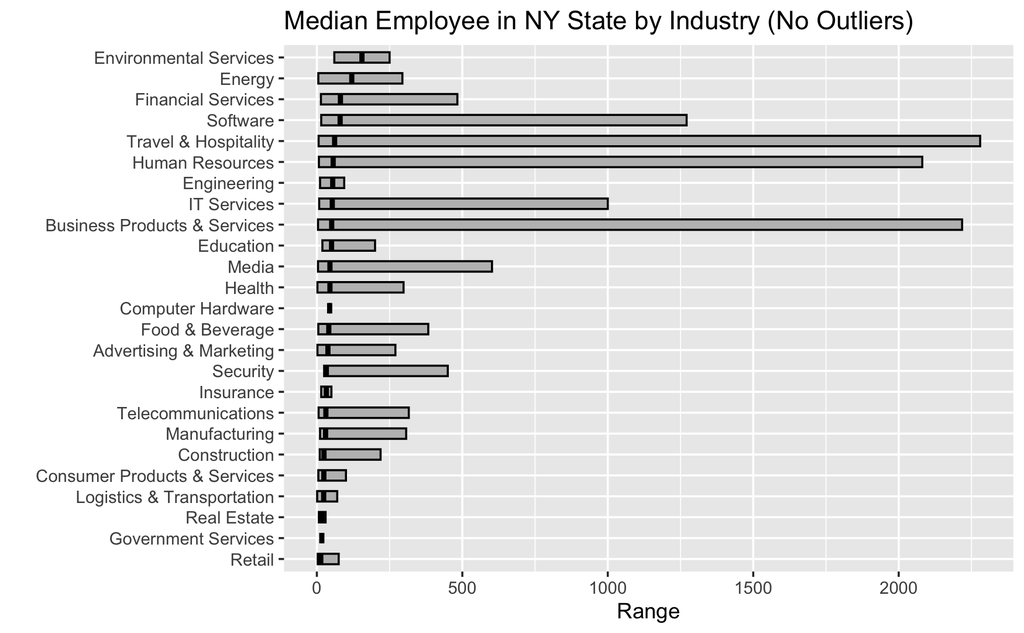

```r
# groupby and plot without outliers
groupby_column(inc_ny_no_outlier, Industry, Employees) %>%
  crossbar_plot(Industry, med_grp, med_grp, min_grp, max_grp,
              title = "Median Employee in NY State by Industry (No Outliers)")
```

This showcases the median and range of `Employees` by `Industry` in NY state. That said, it is important to understand which records were removed. If I had more time I would compute that and experiment with more quantiles.

## Question 3

Now imagine you work for an investor and want to see which industries generate the most revenue per employee. Create a chart that makes this information clear. Once again, the distribution per industry should be shown.

| Industry | n | rev_emp_per_1k |
| --- | --- | --- |
| Energy | 5 | 650 |
| Logistics & Transportation | 4 | 637 |
| IT Services | 43 | 550 |
| Computer Hardware | 1 | 520 |
| Insurance | 2 | 474 |
| Retail | 14 | 473 |
| Consumer Products & Services | 17 | 451 |
| Financial Services | 13 | 404 |
| Telecommunications | 17 | 387 |
| Manufacturing | 13 | 386 |

[output cut: 15 more lines]

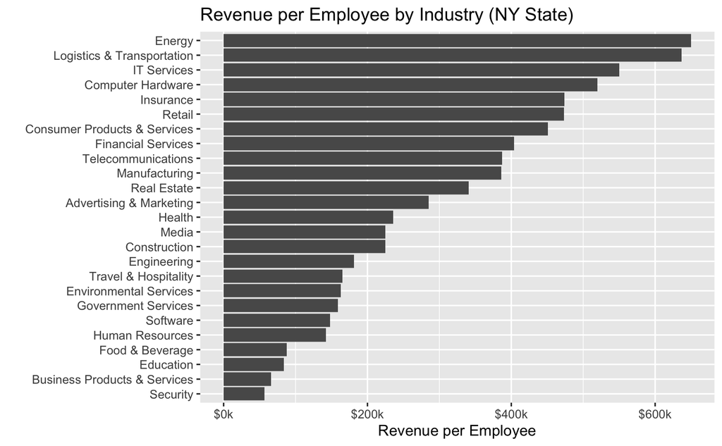

This doesn’t show the distribution, just the revenue per employee, will need to try a different chart.